# Práctica 2: Limpieza y análisis de datos

### 4.3.3 Hipótesis de contraste sobre proporción entre jugadores USA y jugadores RM

Creamos los dataset de jugadores de USA y RM y comparamos las proporciones de jugadores nacidos fuera de USA entre los años 2005 y 2015.

**¿La proporción de jugadores con RM en el 2005 es la misma que en el 2015?**

**Hipótesis nula:** la proprorción de jugadores RM es la misma en el 2005 y en el 2015.

**Hipóteis alternativa:** la proprorción de jugadores RM es diferente en el 2005 y en el 2015.

$$\left\{
\begin{array}{ll}
• \thinspace Hipótesis\thinspace nula\hspace{31pt} H_{0}: & p_{2015} = p_{2005}\\
• \thinspace Hipótesis\thinspace alternativa\thinspace H_{1}: & p_{2015} \neq p_{2005}
\end{array}
\right.$$
Vamos a realizar un test de contraste bilateral sobre la diferencia de dos proporciones, con muestras grandes. Supondremos que cada jugador puede o no puede haber nacido en USA, siendo la proporción muestral $\hat{p_{2015}}$ para el 2015 y $\hat{p_{2005}}$ para el 2005.

• El estadístico de contraste sera:

$$Z=\frac{\hat{p_{2015}}-\hat{p_{2005}}}{\sqrt{p (1-p)(\frac{1}{n_{2015}}+\frac{1}{n_{2005}})}}$$
siendo $p:$
$$p=\frac{n_{2015}\hat{p_{2015}}+n_{2005}\hat{p_{2005}}}{n_{2015}+n_{2005}}$$

Realizaremos el cálculo con un nivel de confianza del $97\%$

```r
# nivel de significación
alpha=0.03

# Calculamos las proporciones
nB <- length(datasetBateadores[['playerID']]);
nM <- length( datasetBateadores.2005[['playerID']] );

pB <- length(bat.rm[['playerID']] )/nB
message("Proporción del 2015: ",pB)
```

```
## Proporción del 2015: 0.271214642262895
```

```r
pM <- length(bat.rm.2005[['playerID']] )/nM
message("Proporción del 2005: ",pM)
```

```
## Proporción del 2005: 0.3
```

```r
p<-(nB*pB + nM*pM) / (nB+nM)

# calculamos valor de observación
zobs <- (pB-pM)/( sqrt(p*(1-p)*(1/nB+1/nM)) )
message("valor de observación: ",zobs)
```

```
## valor de observación: -1.20086307079928
```

```r
tcritL <- qnorm( alpha/2)
tcritU <- qnorm( 1-alpha/2)

# calculamos p-value
pvalue<- pnorm(abs(zobs), lower.tail=FALSE)*2
message("valor de p-value: ",pvalue)
```

```
## valor de p-value: 0.229804321374705
```

Obtenemos

```r
library(kableExtra)
out <- data.frame(prop_2015=pB,prop_2005=pM, n_2015=nB,n_2005=nM,obs_value=zobs,criticalL=tcritL,criticalU=tcritU, pvalue=pvalue)

return(out %>% kable() %>% kable_styling())
```

| prop_2015 | prop_2005 | n_2015 | n_2005 | obs_value | criticalL | criticalU | pvalue |
| --- | --- | --- | --- | --- | --- | --- | --- |
| 0.2712146 | 0.3 | 601 | 880 | -1.200863 | -2.17009 | 2.17009 | 0.2298043 |

Si observamos el cuadro con el resultado, podemos ver que el p-value obtenido es mayor que el nivel de significación y por lo tanto, no se puede rechazar la hipótesis nula de igualdad de proporción de jugadores del Resto del Mundo con jugadores de USA a lo largo de estos 10 años con un nivel de confianza del $97\%$.

# 5 Representación de los resultados a partir de tablas y gráficas.

## 5.1 Comparación de medias salariales entre jugadors USA y RM

Veamos la representación de los salarios para jugadores nacidos en USA y en RM, para el 2015 y 2005 y de esta manera entendemos los resultados.

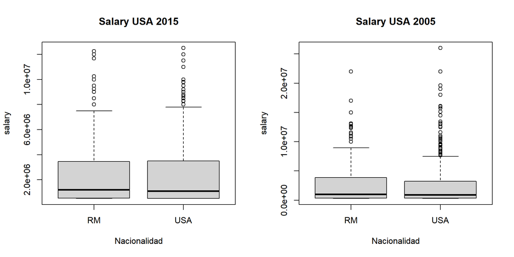

```r
nacionalidad <- vector() # Se crea un vector vacío
nacionalidad[datasetBateadores$birthCountry=='USA'] <- 'USA'
nacionalidad[datasetBateadores$birthCountry!='USA'] <- 'RM'
#delay_SFO <- as.factor(delay_SFO)

datasetBateadores$nacionalidad <- nacionalidad

nacionalidad <- vector() # Se crea un vector vacío
nacionalidad[datasetBateadores.2005$birthCountry=='USA'] <- 'USA'
nacionalidad[datasetBateadores.2005$birthCountry!='USA'] <- 'RM'
#delay_SFO <- as.factor(delay_SFO)

datasetBateadores.2005$nacionalidad <- nacionalidad

par(mfrow=c(1 ,2))

boxplot(salary~nacionalidad,data=datasetBateadores,main="Salary USA 2015", ylab="salary",xlab="Nacionalidad")

boxplot(salary~nacionalidad,data=datasetBateadores.2005,main="Salary USA 2005", ylab="salary",xlab="Nacionalidad")
```

Vemos como la variabilidad era mayor para los jugadores RM en el 2005, pero para el 2015 la distribución entre ambos grupos se hace practicamente igual, lo que confirma los resultados que obtuvimos con respecto al salario entre ambos grupos.

## 5.2 Regresión lineal

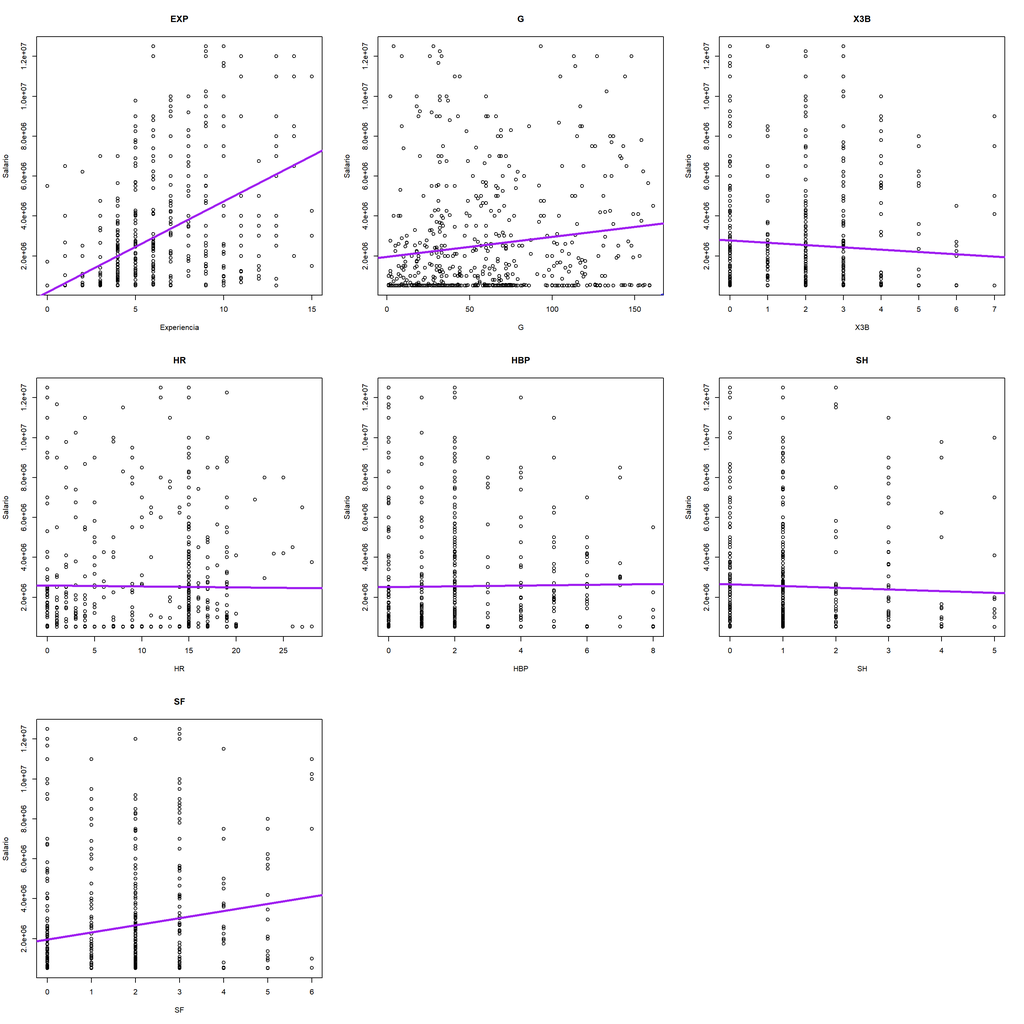

```r
 #G + X3B + HR + HBP + SH + SF
modelo.bat.exp <-lm(salary~Exp,data=datasetBateadores,na.action = na.omit)
sumary<-summary(modelo.bat.exp)
smrs.exp<-sumary$r.squared
modelo.bat.G <-lm(salary~G,data=datasetBateadores,na.action = na.omit)
sumary<-summary(modelo.bat.G)
smrs.G<-sumary$r.squared
modelo.bat.X3B <-lm(salary~X3B,data=datasetBateadores,na.action = na.omit)
sumary<-summary(modelo.bat.X3B)
smrs.X3B<-sumary$r.squared
modelo.bat.HR <-lm(salary~HR,data=datasetBateadores,na.action = na.omit)
sumary<-summary(modelo.bat.HR)
smrs.HR<-sumary$r.squared
modelo.bat.HBP <-lm(salary~HBP,data=datasetBateadores,na.action = na.omit)
sumary<-summary(modelo.bat.HBP)
smrs.HBP<-sumary$r.squared
modelo.bat.SH <-lm(salary~SH,data=datasetBateadores,na.action = na.omit)
sumary<-summary(modelo.bat.SH)
smrs.SH<-sumary$r.squared
modelo.bat.SF <-lm(salary~SF,data=datasetBateadores,na.action = na.omit)
sumary<-summary(modelo.bat.SF)
smrs.SF<-sumary$r.squared

par(mfrow=c(3 ,3))
# Exp + G + X3B + HR + HBP + SH + SF
plot(datasetBateadores$Exp,datasetBateadores$salary,xlab="Experiencia",ylab="Salario",main="EXP")
text(170, 100, labels = round(smrs.exp ,2), col = "blue")
abline(modelo.bat.exp,lwd = 3,col="purple")

plot(datasetBateadores$G,datasetBateadores$salary,xlab="G",ylab="Salario",main="G")
text(170, 100, labels = round(smrs.G ,2), col = "blue")
abline(modelo.bat.G,lwd = 3,col="purple")

plot(datasetBateadores$X3B,datasetBateadores$salary,xlab="X3B",ylab="Salario",main="X3B")
text(170, 100, labels = round(smrs.X3B ,2), col = "blue")
abline(modelo.bat.X3B,lwd = 3,col="purple")

plot(datasetBateadores$HR,datasetBateadores$salary,xlab="HR",ylab="Salario",main="HR")
text(170, 100, labels = round(smrs.HR ,2), col = "blue")
abline(modelo.bat.HR,lwd = 3,col="purple")

plot(datasetBateadores$HBP,datasetBateadores$salary,xlab="HBP",ylab="Salario",main="HBP")
text(170, 100, labels = round(smrs.HBP ,2), col = "blue")
abline(modelo.bat.HBP,lwd = 3,col="purple")

plot(datasetBateadores$SH,datasetBateadores$salary,xlab="SH",ylab="Salario",main="SH")
text(170, 100, labels = round(smrs.SH ,2), col = "blue")
abline(modelo.bat.SH,lwd = 3,col="purple")

plot(datasetBateadores$SF,datasetBateadores$salary,xlab="SF",ylab="Salario",main="SF")
text(170, 100, labels = round(smrs.SF ,2), col = "blue")
abline(modelo.bat.SF,lwd = 3,col="purple")

# Exp + G + X3B + HR + HBP + SH + SF
```

## 5.3 Proporción de jugadores USA y RM

```r
nacionalidad <- vector() # Se crea un vector vacío
nacionalidad[datasetBateadores.10$birthCountry=='USA'] <- 'USA'
nacionalidad[datasetBateadores.10$birthCountry!='USA'] <- 'RM'
#delay_SFO <- as.factor(delay_SFO)

datasetBateadores.10$nacionalidad <- nacionalidad


prop.bat.yr <- table(datasetBateadores.10$nacionalidad, datasetBateadores.10$yearID)
prop.bat.yr <-round(prop.table(x=prop.bat.yr),3)
prop.bat.yr
```

```
##
##        2005  2006  2007  2008  2009  2010  2011  2012  2013  2014  2015
##   RM  0.027 0.027 0.026 0.026 0.025 0.024 0.024 0.027 0.026 0.023 0.025
##   USA 0.063 0.066 0.065 0.065 0.064 0.065 0.065 0.066 0.065 0.066 0.068
```

Representamos estas proporciones y vemos que las proporciones no tienen cambios significativos a lo largo de estos 10 años.

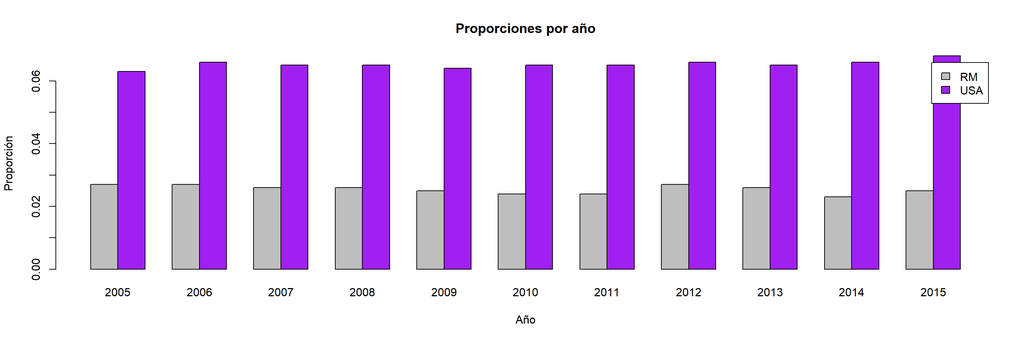

```r
barplot(prop.bat.yr, main="Proporciones por año", xlab="Año", ylab="Proporción", col=c("gray","purple"),
        legend = rownames(prop.bat.yr),   beside=TRUE)
```

# 6 ¿cuáles son las conclusiones? ¿Los resultados permiten responder al problema?

Según lo que hemos visto, los resultados nos permiten responder a dos de las cuestiones, sobre los salarios de los dos grupos de jugadores nacidos en USA y RM y sobre si la proprorción de estos grupos a lo largo de los años se ha mantenido, sin embargo, no hemos podido explicar el salario de los jugadores a partir de las caracteristicas de juego de cada jugador.